# Google Data Analytics Capstone Project

# 1. Summary

## 1.1 About the Company

Bellabeat adalah perusahaan high-tech manufacturer yang berfokus pada produk kesehatan khusus wanita. Bellabeat didirikan pada tahun 2013 dan telah berkembang pesat dan dengan cepat memposisikan dirinya sebagai perusahaan kesehatan berbasis teknologi wanita. Pada tahun 2016, Bellabeat telah membuka kantor diseluruh dunia dan meluncurkan beberapa produk. Perusahaan telah berinvestasi di media periklanan tradisional, seperti radio, papan reklame luar rumah, media cetak, dan televisi, tetapi berfokus pada pemasaran digital secara ekstensif. Bellabeat berinvestasi sepanjang tahun di Google Search, memelihara halaman Facebook dan Instagram yang aktif, dan secara konsisten melibatkan konsumen di Twitter. Selain itu, Bellabeat meluncurkan iklan video di Youtube dan menampilkan iklan di Google Display Network untuk mendukung kampanye seputar tanggal pemasaran penting.

## 1.2 Scenario

Saya adalah seorang data analis junior yang bekerja di tim pemasaran di Bellabeat. Bellabeat adalah perusahaan kecil yang sukses, tetapi memiliki potensi untuk menjadi pemain yang lebih besar di pasar perangkat pintar globa.Mengumpulkan data tentang aktivitas, tidur, stres, dan kesehatan reproduksi telah memungkinkan Bellabeat untuk memberdayakan wanita dengan pengetahuan tentang kesehatan dan kebiasaan mereka sendiri.

Urška Sršen, salah satu pendiri dan Chief Creative Officer Bellabeat, percaya bahwa menganalisis data kebugaran dari perangkat pintar dapat membantu membuka peluang pertumbuhan baru bagi perusahaan. Urška Sršen meminta saya untuk menganalisis data penggunaan perangkat pintar untuk mendapatkan wawasan tentang bagaimana konsumen menggunakan perangkat pintar non-Bellabeat. Kemudian memilih satu produk Bellabeat untuk menerapkan wawasan ini dalam presentasi.

## 1.2 Analysis Questions

1. Apa saja tren dalam penggunaan perangkat pintar?
2. Bagaimana tren ini dapat diterapkan pada pelanggan Bellabeat?
3. Bagaimana tren ini dapat membantu memengaruhi strategi pemasaran Bellabeat?

## 1.3 Data Source

Data yang digunakan **FitBit Fitness Tracker Data** dari kaggle, klik disini untuk langsung menuju dataset.

# 2. Ask Phase

## 2.1 Business Plan

Menganalisis data pengguna smart device untuk mendapat wawasan tentang bagaimana konsumen menggunakan smart device mereka dan memperoleh rekomendasi tetang tren untuk membantu penyusunan strategi pemasaran Bellabeat.

## 2.2 Stakeholders

1. **Urška Sršen**: Salah satu pendiri Bellabeat dan Chief Creative Oﬃcer
2. **Sando Mur**: Matematikawan dan salah satu pendiri Bellabeat; anggota kunci dari tim eksekutif Bellabeat
3. **Tim analisis pemasaran Bellabeat**: Sebuah tim analis data yang bertanggung jawab untuk mengumpulkan, menganalisis, dan melaporkan data yang dapat membantu penyusunan strategi pemasaran Bellabeat. Saya bergabung dengan tim ini enam bulan lalu dan sibuk mempelajari misi dan tujuan bisnis Bellabeat — serta bagaimana Saya, sebagai analis data junior, dapat membantu Bellabeat untuk mencapainya.

# 3. Prepare Phase

## 3.3 Licensing, privacy, accessibility

Data dapat diakses secara publik atau dapat diakses oleh siapa saja, Sehingga dataset ini dapat dengan bebas digunakan, diakses, dimodifikasi atau di distribusi tanpa perlu izin sebelumnya.

# 4. Process Phase

## 4.1 Installing and import packages / libraries

```r
# Install packages
#install.packages('tidyverse')
#install.packages('janitor')
```

```r
# Import libraries
library(tidyverse)
library(janitor)
library(dplyr)
```

## 4.2 Loading dataset

```r
# Loading dataset daily
weight_log <- read_csv("weightLogInfo_merged.csv")
sleep_day <- read_csv("sleepDay_merged.csv")
daily_activity <- read_csv("dailyActivity_merged.csv")
heartrate <- read_csv("heartrate_seconds_merged.csv")
```

## 4.3 Checking the heads

```r
# Checking the heads
head(daily_activity)
```

| Id | ActivityDate | TotalSteps | TotalDistance | TrackerDistance | LoggedActivitiesDistance | VeryActiveDistance | ModeratelyActiveDistance | LightActiveDistance | SedentaryActiveDistance | VeryActiveMinutes | FairlyActiveMinutes | LightlyActiveMinutes | SedentaryMinutes | Calories |
| --- | --- | --- | --- | --- | --- | --- | --- | --- | --- | --- | --- | --- | --- | --- |
| 1503960366 | 4/12/2016 | 13162 | 8.50 | 8.50 | 0 | 1.88 | 0.55 | 6.06 | 0 | 25 | 13 | 328 | 728 | 1985 |
| 1503960366 | 4/13/2016 | 10735 | 6.97 | 6.97 | 0 | 1.57 | 0.69 | 4.71 | 0 | 21 | 19 | 217 | 776 | 1797 |
| 1503960366 | 4/14/2016 | 10460 | 6.74 | 6.74 | 0 | 2.44 | 0.40 | 3.91 | 0 | 30 | 11 | 181 | 1218 | 1776 |
| 1503960366 | 4/15/2016 | 9762 | 6.28 | 6.28 | 0 | 2.14 | 1.26 | 2.83 | 0 | 29 | 34 | 209 | 726 | 1745 |
| 1503960366 | 4/16/2016 | 12669 | 8.16 | 8.16 | 0 | 2.71 | 0.41 | 5.04 | 0 | 36 | 10 | 221 | 773 | 1863 |
| 1503960366 | 4/17/2016 | 9705 | 6.48 | 6.48 | 0 | 3.19 | 0.78 | 2.51 | 0 | 38 | 20 | 164 | 539 | 1728 |

```r
str(daily_activity)
```

```
spc_tbl_ [940 × 15] (S3: spec_tbl_df/tbl_df/tbl/data.frame)
 $ Id                      : num [1:940] 1.5e+09 1.5e+09 1.5e+09 1.5e+09 1.5e+09 ...
 $ ActivityDate            : chr [1:940] "4/12/2016" "4/13/2016" "4/14/2016" "4/15/2016" ...
 $ TotalSteps              : num [1:940] 13162 10735 10460 9762 12669 ...
 $ TotalDistance           : num [1:940] 8.5 6.97 6.74 6.28 8.16 ...
 $ TrackerDistance         : num [1:940] 8.5 6.97 6.74 6.28 8.16 ...
 $ LoggedActivitiesDistance: num [1:940] 0 0 0 0 0 0 0 0 0 0 ...
 $ VeryActiveDistance      : num [1:940] 1.88 1.57 2.44 2.14 2.71 ...
 $ ModeratelyActiveDistance: num [1:940] 0.55 0.69 0.4 1.26 0.41 ...
 $ LightActiveDistance     : num [1:940] 6.06 4.71 3.91 2.83 5.04 ...
 $ SedentaryActiveDistance : num [1:940] 0 0 0 0 0 0 0 0 0 0 ...
 $ VeryActiveMinutes       : num [1:940] 25 21 30 29 36 38 42 50 28 19 ...
 $ FairlyActiveMinutes     : num [1:940] 13 19 11 34 10 20 16 31 12 8 ...
 $ LightlyActiveMinutes    : num [1:940] 328 217 181 209 221 164 233 264 205 211 ...
 $ SedentaryMinutes        : num [1:940] 728 776 1218 726 773 ...
 $ Calories                : num [1:940] 1985 1797 1776 1745 1863 ...
 - attr(*, "spec")=
  .. cols(
  ..   Id = col_double(),
  ..   ActivityDate = col_character(),
  ..   TotalSteps = col_double(),
  ..   TotalDistance = col_double(),
  ..   TrackerDistance = col_double(),
  ..   LoggedActivitiesDistance = col_double(),
  ..   VeryActiveDistance = col_double(),
  ..   ModeratelyActiveDistance = col_double(),
  ..   LightActiveDistance = col_double(),
  ..   SedentaryActiveDistance = col_double(),
  ..   VeryActiveMinutes = col_double(),
  ..   FairlyActiveMinutes = col_double(),
  ..   LightlyActiveMinutes = col_double(),
  ..   SedentaryMinutes = col_double(),
  ..   Calories = col_double()
  .. )
 - attr(*, "problems")=<externalptr>
```

```r
head(heartrate)
```

| Id | Time | Value |
| --- | --- | --- |
| 2022484408 | 4/12/2016 7:21:00 AM | 97 |
| 2022484408 | 4/12/2016 7:21:05 AM | 102 |
| 2022484408 | 4/12/2016 7:21:10 AM | 105 |
| 2022484408 | 4/12/2016 7:21:20 AM | 103 |
| 2022484408 | 4/12/2016 7:21:25 AM | 101 |
| 2022484408 | 4/12/2016 7:22:05 AM | 95 |

```r
str(heartrate)
```

```
spc_tbl_ [2,483,658 × 3] (S3: spec_tbl_df/tbl_df/tbl/data.frame)
 $ Id   : num [1:2483658] 2.02e+09 2.02e+09 2.02e+09 2.02e+09 2.02e+09 ...
 $ Time : chr [1:2483658] "4/12/2016 7:21:00 AM" "4/12/2016 7:21:05 AM" "4/12/2016 7:21:10 AM" "4/12/2016 7:21:20 AM" ...
 $ Value: num [1:2483658] 97 102 105 103 101 95 91 93 94 93 ...
 - attr(*, "spec")=
  .. cols(
  ..   Id = col_double(),
  ..   Time = col_character(),
  ..   Value = col_double()
  .. )
 - attr(*, "problems")=<externalptr>
```

```r
head(sleep_day)
```

| Id | SleepDay | TotalSleepRecords | TotalMinutesAsleep | TotalTimeInBed |
| --- | --- | --- | --- | --- |
| 1503960366 | 4/12/2016 12:00:00 AM | 1 | 327 | 346 |
| 1503960366 | 4/13/2016 12:00:00 AM | 2 | 384 | 407 |
| 1503960366 | 4/15/2016 12:00:00 AM | 1 | 412 | 442 |
| 1503960366 | 4/16/2016 12:00:00 AM | 2 | 340 | 367 |
| 1503960366 | 4/17/2016 12:00:00 AM | 1 | 700 | 712 |
| 1503960366 | 4/19/2016 12:00:00 AM | 1 | 304 | 320 |

```r
str(sleep_day)
```

```
spc_tbl_ [413 × 5] (S3: spec_tbl_df/tbl_df/tbl/data.frame)
 $ Id                : num [1:413] 1.5e+09 1.5e+09 1.5e+09 1.5e+09 1.5e+09 ...
 $ SleepDay          : chr [1:413] "4/12/2016 12:00:00 AM" "4/13/2016 12:00:00 AM" "4/15/2016 12:00:00 AM" "4/16/2016 12:00:00 AM" ...
 $ TotalSleepRecords : num [1:413] 1 2 1 2 1 1 1 1 1 1 ...
 $ TotalMinutesAsleep: num [1:413] 327 384 412 340 700 304 360 325 361 430 ...
 $ TotalTimeInBed    : num [1:413] 346 407 442 367 712 320 377 364 384 449 ...
 - attr(*, "spec")=
  .. cols(
  ..   Id = col_double(),
  ..   SleepDay = col_character(),
  ..   TotalSleepRecords = col_double(),
  ..   TotalMinutesAsleep = col_double(),
  ..   TotalTimeInBed = col_double()
  .. )
 - attr(*, "problems")=<externalptr>
```

```r
head(weight_log)
```

| Id | Date | WeightKg | WeightPounds | Fat | BMI | IsManualReport | LogId |
| --- | --- | --- | --- | --- | --- | --- | --- |
| 1503960366 | 5/2/2016 11:59:59 PM | 52.6 | 115.9631 | 22 | 22.65 | TRUE | 1.462234e+12 |
| 1503960366 | 5/3/2016 11:59:59 PM | 52.6 | 115.9631 | NA | 22.65 | TRUE | 1.462320e+12 |
| 1927972279 | 4/13/2016 1:08:52 AM | 133.5 | 294.3171 | NA | 47.54 | FALSE | 1.460510e+12 |
| 2873212765 | 4/21/2016 11:59:59 PM | 56.7 | 125.0021 | NA | 21.45 | TRUE | 1.461283e+12 |
| 2873212765 | 5/12/2016 11:59:59 PM | 57.3 | 126.3249 | NA | 21.69 | TRUE | 1.463098e+12 |
| 4319703577 | 4/17/2016 11:59:59 PM | 72.4 | 159.6147 | 25 | 27.45 | TRUE | 1.460938e+12 |

```r
str(weight_log)
```

```
spc_tbl_ [67 × 8] (S3: spec_tbl_df/tbl_df/tbl/data.frame)
 $ Id            : num [1:67] 1.50e+09 1.50e+09 1.93e+09 2.87e+09 2.87e+09 ...
 $ Date          : chr [1:67] "5/2/2016 11:59:59 PM" "5/3/2016 11:59:59 PM" "4/13/2016 1:08:52 AM" "4/21/2016 11:59:59 PM" ...
 $ WeightKg      : num [1:67] 52.6 52.6 133.5 56.7 57.3 ...
 $ WeightPounds  : num [1:67] 116 116 294 125 126 ...
 $ Fat           : num [1:67] 22 NA NA NA NA 25 NA NA NA NA ...
 $ BMI           : num [1:67] 22.6 22.6 47.5 21.5 21.7 ...
 $ IsManualReport: logi [1:67] TRUE TRUE FALSE TRUE TRUE TRUE ...
 $ LogId         : num [1:67] 1.46e+12 1.46e+12 1.46e+12 1.46e+12 1.46e+12 ...
 - attr(*, "spec")=
  .. cols(
  ..   Id = col_double(),
  ..   Date = col_character(),
  ..   WeightKg = col_double(),
  ..   WeightPounds = col_double(),
  ..   Fat = col_double(),
  ..   BMI = col_double(),
  ..   IsManualReport = col_logical(),
  ..   LogId = col_double()
  .. )
 - attr(*, "problems")=<externalptr>
```

## 4.4 Cleaning the data

Pada tahap cleaning akan di cek data yang memiliki missing value, duplicate, changing data type dan rename columns.

### Checking missing values

```r
# Checking missing value
sum(is.na(daily_activity))
```

```
[1] 0
```

```r
sum(is.na(heartrate))
```

```
[1] 0
```

```r
sum(is.na(sleep_day))
```

```
[1] 0
```

```r
sum(is.na(weight_log))
```

```
[1] 65
```

Terdapat missing values pada tabel **weight_log** yaitu sebanyak 65, akan dicek data manakah yang memiliki missing values

```r
# Checking indeks missing values
apply(is.na(weight_log),2,which)
```

```
$Id
integer(0)

$Date
integer(0)

$WeightKg
integer(0)

$WeightPounds
integer(0)

$Fat
 [1]  2  3  4  5  7  8  9 10 11 12 13 14 15 16 17 18 19 20 21 22 23 24 25 26 27 28 29 30 31 32 33 34 35 36 37 38 39 40 41 42 43 44 45 46 47 48 49 50
[49] 51 52 53 54 55 56 57 58 59 60 61 62 63 64 65 66 67

$BMI
integer(0)

$IsManualReport
integer(0)

$LogId
integer(0)
```

Missing value hanya pada kolum **Fat** dengan jumlah hampir seluruhnya tidak memiliki data, Maka kolom **Fat akan dihapus**

```r
# Cleaning column Fat in table weigh_log
weight_log <- weight_log %>%
  select(-Fat)
```

```r
# Checking missing values weight_log is gone
apply(is.na(weight_log),2, which)
```

```
integer(0)
```

Missing values sudah berhasil di handle

### Checking duplicate data

```r
# Checking duplicate data
sum(duplicated(daily_activity))
```

```
[1] 0
```

```r
sum(duplicated(heartrate))
```

```
[1] 0
```

```r
sum(duplicated(sleep_day))
```

```
[1] 3
```

```r
sum(duplicated(weight_log))
```

```
[1] 0
```

```r
# Checking data duplicate in sleep_day
sleep_day[duplicated(sleep_day), ]
```

| Id | SleepDay | TotalSleepRecords | TotalMinutesAsleep | TotalTimeInBed |
| --- | --- | --- | --- | --- |
| 4388161847 | 5/5/2016 12:00:00 AM | 1 | 471 | 495 |
| 4702921684 | 5/7/2016 12:00:00 AM | 1 | 520 | 543 |
| 8378563200 | 4/25/2016 12:00:00 AM | 1 | 388 | 402 |

```r
# Remove duplicate data
sleep_day <- sleep_day %>%
  distinct()%>%
  drop_na()
```

```r
# Checking duplicate is gone
sum(duplicated(sleep_day))
```

```
[1] 0
```

### Changing data type

Semua dataset memiliki tipe data character yang seharus tipe data date, makan akan diubah

```r
# Changing data type character to date and datetime
daily_activity$ActivityDate <- mdy(daily_activity$ActivityDate)
heartrate$Time <- mdy_hms(heartrate$Time)
sleep_day$SleepDay <- mdy_hms(sleep_day$SleepDay)
weight_log$Date <- mdy_hms(weight_log$Date)
```

```r
# Checking the head
head(sleep_day)
```

| Id | SleepDay | TotalSleepRecords | TotalMinutesAsleep | TotalTimeInBed |
| --- | --- | --- | --- | --- |
| 1503960366 | 2016-04-12 | 1 | 327 | 346 |
| 1503960366 | 2016-04-13 | 2 | 384 | 407 |
| 1503960366 | 2016-04-15 | 1 | 412 | 442 |
| 1503960366 | 2016-04-16 | 2 | 340 | 367 |
| 1503960366 | 2016-04-17 | 1 | 700 | 712 |
| 1503960366 | 2016-04-19 | 1 | 304 | 320 |

### Rename columns

Untuk menjaga konsistensi dan format yang sama untuk semua data, maka akan mengubah format semua kolom menjadi huruf kecil

```r
clean_names(daily_activity)
```

| id | activity_date | total_steps | total_distance | tracker_distance | logged_activities_distance | very_active_distance | moderately_active_distance | light_active_distance | sedentary_active_distance | very_active_minutes | fairly_active_minutes | lightly_active_minutes | sedentary_minutes | calories |
| --- | --- | --- | --- | --- | --- | --- | --- | --- | --- | --- | --- | --- | --- | --- |
| 1503960366 | 2016-04-12 | 13162 | 8.50 | 8.50 | 0.000000 | 1.88 | 0.55 | 6.06 | 0.00 | 25 | 13 | 328 | 728 | 1985 |
| 1503960366 | 2016-04-13 | 10735 | 6.97 | 6.97 | 0.000000 | 1.57 | 0.69 | 4.71 | 0.00 | 21 | 19 | 217 | 776 | 1797 |
| 1503960366 | 2016-04-14 | 10460 | 6.74 | 6.74 | 0.000000 | 2.44 | 0.40 | 3.91 | 0.00 | 30 | 11 | 181 | 1218 | 1776 |
| 1503960366 | 2016-04-15 | 9762 | 6.28 | 6.28 | 0.000000 | 2.14 | 1.26 | 2.83 | 0.00 | 29 | 34 | 209 | 726 | 1745 |
| 1503960366 | 2016-04-16 | 12669 | 8.16 | 8.16 | 0.000000 | 2.71 | 0.41 | 5.04 | 0.00 | 36 | 10 | 221 | 773 | 1863 |
| 1503960366 | 2016-04-17 | 9705 | 6.48 | 6.48 | 0.000000 | 3.19 | 0.78 | 2.51 | 0.00 | 38 | 20 | 164 | 539 | 1728 |
| 1503960366 | 2016-04-18 | 13019 | 8.59 | 8.59 | 0.000000 | 3.25 | 0.64 | 4.71 | 0.00 | 42 | 16 | 233 | 1149 | 1921 |
| 1503960366 | 2016-04-19 | 15506 | 9.88 | 9.88 | 0.000000 | 3.53 | 1.32 | 5.03 | 0.00 | 50 | 31 | 264 | 775 | 2035 |
| 1503960366 | 2016-04-20 | 10544 | 6.68 | 6.68 | 0.000000 | 1.96 | 0.48 | 4.24 | 0.00 | 28 | 12 | 205 | 818 | 1786 |
| 1503960366 | 2016-04-21 | 9819 | 6.34 | 6.34 | 0.000000 | 1.34 | 0.35 | 4.65 | 0.00 | 19 | 8 | 211 | 838 | 1775 |

[output cut: 930 more lines]

```r
daily_activity <- rename_with(daily_activity, tolower)

clean_names(heartrate)
```

| id | time | value |
| --- | --- | --- |
| 2022484408 | 2016-04-12 07:21:00 | 97 |
| 2022484408 | 2016-04-12 07:21:05 | 102 |
| 2022484408 | 2016-04-12 07:21:10 | 105 |
| 2022484408 | 2016-04-12 07:21:20 | 103 |
| 2022484408 | 2016-04-12 07:21:25 | 101 |
| 2022484408 | 2016-04-12 07:22:05 | 95 |
| 2022484408 | 2016-04-12 07:22:10 | 91 |
| 2022484408 | 2016-04-12 07:22:15 | 93 |
| 2022484408 | 2016-04-12 07:22:20 | 94 |
| 2022484408 | 2016-04-12 07:22:25 | 93 |

[output cut: 990 more lines]

```r
heartrate <- rename_with(heartrate, tolower)

clean_names(sleep_day)
```

| id | sleep_day | total_sleep_records | total_minutes_asleep | total_time_in_bed |
| --- | --- | --- | --- | --- |
| 1503960366 | 2016-04-12 | 1 | 327 | 346 |
| 1503960366 | 2016-04-13 | 2 | 384 | 407 |
| 1503960366 | 2016-04-15 | 1 | 412 | 442 |
| 1503960366 | 2016-04-16 | 2 | 340 | 367 |
| 1503960366 | 2016-04-17 | 1 | 700 | 712 |
| 1503960366 | 2016-04-19 | 1 | 304 | 320 |
| 1503960366 | 2016-04-20 | 1 | 360 | 377 |
| 1503960366 | 2016-04-21 | 1 | 325 | 364 |
| 1503960366 | 2016-04-23 | 1 | 361 | 384 |
| 1503960366 | 2016-04-24 | 1 | 430 | 449 |

[output cut: 400 more lines]

```r
sleep_day <- rename_with(sleep_day, tolower)

clean_names(weight_log)
```

| id | date | weight_kg | weight_pounds | bmi | is_manual_report | log_id |
| --- | --- | --- | --- | --- | --- | --- |
| 1503960366 | 2016-05-02 23:59:59 | 52.6 | 115.9631 | 22.65 | TRUE | 1.462234e+12 |
| 1503960366 | 2016-05-03 23:59:59 | 52.6 | 115.9631 | 22.65 | TRUE | 1.462320e+12 |
| 1927972279 | 2016-04-13 01:08:52 | 133.5 | 294.3171 | 47.54 | FALSE | 1.460510e+12 |
| 2873212765 | 2016-04-21 23:59:59 | 56.7 | 125.0021 | 21.45 | TRUE | 1.461283e+12 |
| 2873212765 | 2016-05-12 23:59:59 | 57.3 | 126.3249 | 21.69 | TRUE | 1.463098e+12 |
| 4319703577 | 2016-04-17 23:59:59 | 72.4 | 159.6147 | 27.45 | TRUE | 1.460938e+12 |
| 4319703577 | 2016-05-04 23:59:59 | 72.3 | 159.3942 | 27.38 | TRUE | 1.462406e+12 |
| 4558609924 | 2016-04-18 23:59:59 | 69.7 | 153.6622 | 27.25 | TRUE | 1.461024e+12 |
| 4558609924 | 2016-04-25 23:59:59 | 70.3 | 154.9850 | 27.46 | TRUE | 1.461629e+12 |
| 4558609924 | 2016-05-01 23:59:59 | 69.9 | 154.1031 | 27.32 | TRUE | 1.462147e+12 |

[output cut: 57 more lines]

```r
weight_log <- rename_with(weight_log, tolower)
```

```r
daily_activity %>%
  rename(date=activitydate)
```

| id | date | totalsteps | totaldistance | trackerdistance | loggedactivitiesdistance | veryactivedistance | moderatelyactivedistance | lightactivedistance | sedentaryactivedistance | veryactiveminutes | fairlyactiveminutes | lightlyactiveminutes | sedentaryminutes | calories |
| --- | --- | --- | --- | --- | --- | --- | --- | --- | --- | --- | --- | --- | --- | --- |
| 1503960366 | 2016-04-12 | 13162 | 8.50 | 8.50 | 0.000000 | 1.88 | 0.55 | 6.06 | 0.00 | 25 | 13 | 328 | 728 | 1985 |
| 1503960366 | 2016-04-13 | 10735 | 6.97 | 6.97 | 0.000000 | 1.57 | 0.69 | 4.71 | 0.00 | 21 | 19 | 217 | 776 | 1797 |
| 1503960366 | 2016-04-14 | 10460 | 6.74 | 6.74 | 0.000000 | 2.44 | 0.40 | 3.91 | 0.00 | 30 | 11 | 181 | 1218 | 1776 |
| 1503960366 | 2016-04-15 | 9762 | 6.28 | 6.28 | 0.000000 | 2.14 | 1.26 | 2.83 | 0.00 | 29 | 34 | 209 | 726 | 1745 |
| 1503960366 | 2016-04-16 | 12669 | 8.16 | 8.16 | 0.000000 | 2.71 | 0.41 | 5.04 | 0.00 | 36 | 10 | 221 | 773 | 1863 |
| 1503960366 | 2016-04-17 | 9705 | 6.48 | 6.48 | 0.000000 | 3.19 | 0.78 | 2.51 | 0.00 | 38 | 20 | 164 | 539 | 1728 |
| 1503960366 | 2016-04-18 | 13019 | 8.59 | 8.59 | 0.000000 | 3.25 | 0.64 | 4.71 | 0.00 | 42 | 16 | 233 | 1149 | 1921 |
| 1503960366 | 2016-04-19 | 15506 | 9.88 | 9.88 | 0.000000 | 3.53 | 1.32 | 5.03 | 0.00 | 50 | 31 | 264 | 775 | 2035 |
| 1503960366 | 2016-04-20 | 10544 | 6.68 | 6.68 | 0.000000 | 1.96 | 0.48 | 4.24 | 0.00 | 28 | 12 | 205 | 818 | 1786 |
| 1503960366 | 2016-04-21 | 9819 | 6.34 | 6.34 | 0.000000 | 1.34 | 0.35 | 4.65 | 0.00 | 19 | 8 | 211 | 838 | 1775 |

[output cut: 930 more lines]

```r
sleep_day %>%
  rename(date=sleepday)
```

| id | date | totalsleeprecords | totalminutesasleep | totaltimeinbed |
| --- | --- | --- | --- | --- |
| 1503960366 | 2016-04-12 | 1 | 327 | 346 |
| 1503960366 | 2016-04-13 | 2 | 384 | 407 |
| 1503960366 | 2016-04-15 | 1 | 412 | 442 |
| 1503960366 | 2016-04-16 | 2 | 340 | 367 |
| 1503960366 | 2016-04-17 | 1 | 700 | 712 |
| 1503960366 | 2016-04-19 | 1 | 304 | 320 |
| 1503960366 | 2016-04-20 | 1 | 360 | 377 |
| 1503960366 | 2016-04-21 | 1 | 325 | 364 |
| 1503960366 | 2016-04-23 | 1 | 361 | 384 |
| 1503960366 | 2016-04-24 | 1 | 430 | 449 |

[output cut: 400 more lines]

## 4.5 Mergering datasets

Pada tahap ini tabel daily_activity akan digabungkan dengan tabel sleep_day dengan id dan date sebagai primary keys.

```r
# Merge data
daily_merged <- merge(x=daily_activity, y=sleep_day, by.x = c("id", "activitydate"), by.y = c("id", "sleepday"))
```

```r
# Check merge data
head(daily_merged)
```

|  | id | activitydate | totalsteps | totaldistance | trackerdistance | loggedactivitiesdistance | veryactivedistance | moderatelyactivedistance | lightactivedistance | sedentaryactivedistance | veryactiveminutes | fairlyactiveminutes | lightlyactiveminutes | sedentaryminutes | calories | totalsleeprecords | totalminutesasleep | totaltimeinbed |
| --- | --- | --- | --- | --- | --- | --- | --- | --- | --- | --- | --- | --- | --- | --- | --- | --- | --- | --- |
| 1 | 1503960366 | 2016-04-12 | 13162 | 8.50 | 8.50 | 0 | 1.88 | 0.55 | 6.06 | 0 | 25 | 13 | 328 | 728 | 1985 | 1 | 327 | 346 |
| 2 | 1503960366 | 2016-04-13 | 10735 | 6.97 | 6.97 | 0 | 1.57 | 0.69 | 4.71 | 0 | 21 | 19 | 217 | 776 | 1797 | 2 | 384 | 407 |
| 3 | 1503960366 | 2016-04-15 | 9762 | 6.28 | 6.28 | 0 | 2.14 | 1.26 | 2.83 | 0 | 29 | 34 | 209 | 726 | 1745 | 1 | 412 | 442 |
| 4 | 1503960366 | 2016-04-16 | 12669 | 8.16 | 8.16 | 0 | 2.71 | 0.41 | 5.04 | 0 | 36 | 10 | 221 | 773 | 1863 | 2 | 340 | 367 |
| 5 | 1503960366 | 2016-04-17 | 9705 | 6.48 | 6.48 | 0 | 3.19 | 0.78 | 2.51 | 0 | 38 | 20 | 164 | 539 | 1728 | 1 | 700 | 712 |
| 6 | 1503960366 | 2016-04-19 | 15506 | 9.88 | 9.88 | 0 | 3.53 | 1.32 | 5.03 | 0 | 50 | 31 | 264 | 775 | 2035 | 1 | 304 | 320 |

# 5. Analyze Phase

```r
n_distinct(daily_activity$id)
```

```
[1] 33
```

```r
n_distinct(sleep_day$id)
```

```
[1] 24
```

```r
n_distinct(weight_log$id)
```

```
[1] 8
```

```r
n_distinct(heartrate$id)
```

```
[1] 14
```

## 5.1 Smart Device Usage Analysis

### 5.1.1 Days user usage smart device patterns

Pada tahap ini untuk menganalisa berapa banyak penggunaan smart device yang benar benar menggunak alatnyaq. Penelitian ini dilakukan selama 31 hari. Sehingga saya akan membaginya menjadi **4 kategori** pengguna. Berikut bentuk kategorinya:

1. completed use: Kategoru pengguna penuh salama 31 hari.
2. high used: Kategori pengguna menggunakan device antara 21 - 31 hari setiap bulannya.
3. moderate used: Kategori pengguna menggunakan device anatar 11 - 20 hari setiap bulannya.
4. low used: kategori pengguna menggunakan device dibawah 10 hari setiap bulannya.

```r
# Create new dataframe for classifications
daily_used <- daily_merged %>%
  group_by(id) %>%
  summarize(days_used = sum(n())) %>%
  mutate(category = case_when(
    days_used == 31 ~ "1. Completed use",
    days_used >= 21 & days_used <= 31 ~ "2. High Used",
    days_used >= 11 & days_used <= 20 ~ "3. Moderate Used",
    days_used >= 1 & days_used <= 10 ~ "4. Low Used"
  ))

# View new data frame
head(daily_used)
```

| id | days_used | category |
| --- | --- | --- |
| 1503960366 | 25 | 2. High Used |
| 1644430081 | 4 | 4. Low Used |
| 1844505072 | 3 | 4. Low Used |
| 1927972279 | 5 | 4. Low Used |
| 2026352035 | 28 | 2. High Used |
| 2320127002 | 1 | 4. Low Used |

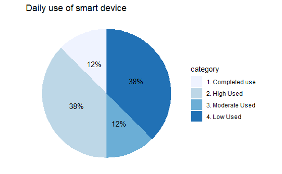

```r
# Create percentage for daily used
daily_used_percent <- daily_used %>%
  group_by(category) %>%
  summarise(total_n = n()) %>%
  mutate(total_sum = sum(total_n)) %>%
  group_by(category) %>%
  summarise(total_percent = total_n / total_sum) %>%
  mutate(labels = scales::percent(total_percent))

# Create pie chart
daily_used_percent %>%
  ggplot(aes(x="", y=total_percent, fill=category)) +
  geom_bar(stat="identity", width = 1) +
  coord_polar("y", start = 0) +
  theme_void() +
  geom_text(aes(label = labels),
            position = position_stack(vjust = 0.5)) +
  scale_fill_brewer(palette = "Blues" ) +
                    #labels = c ("High use", "Moderate use", "Low uses")) +

  labs(title = "Daily use of smart device")
```

```r
print(daily_used_percent)
```

| category | total_percent | labels |
| --- | --- | --- |
| 1. Completed use | 0.125 | 12% |
| 2. High Used | 0.375 | 38% |
| 3. Moderate Used | 0.125 | 12% |
| 4. Low Used | 0.375 | 38% |

```r
NA
```